# Inferring AI-Act-Relevant Application Contexts from Prompts for Enterprise Chatbot Governance

AI and neural networks, 10 September 2026, ECDA 2026, Stralsund

**Michael Bücker**, Christoph Buchmüller,  
Jan Wobker, Leonard Rink  
FH Münster

# 1 Motivation and research question

### Enterprise assistants combine many tasks in one interface

Companies give employees access to general-purpose language models through:

- general chat portals and office or coding copilots
- assistants connected to company documents and tools
- chat interfaces in service, HR, or analytics applications

These systems accept open-ended requests. Policies, training, and access controls do not ensure that every prompt remains within an approved use.

[figure not shown]

Example: Langdock enterprise assistant interface.

**Important**

The same interface can summarise a policy or rank job applicants. Governance must therefore consider each request, not only access to the model.

### Risk categories in the EU AI Act

[figure not shown]

Authors’ illustration based on the legal sources cited below.

### AI Act risk depends on context beyond the prompt

**Four regulatory categories**

- **Minimal:** no specific obligations
- **Limited:** transparency obligations
- **High:** requirements for listed uses
- **Unacceptable:** prohibited practices

The category follows from the AI system’s **intended purpose and use** [1].

**One prompt, several possible contexts**

*“Write code for emotion recognition.”*

- a local technical demonstration
- use in a school
- use in the workplace

The prompt alone does not reveal who will deploy the system, where it will operate, or who it will affect.

**Important**

The classifier estimates a **policy signal from the prompt**. It does not determine the legal category of a deployed AI system.

### Research question and gap

**Research question**

How reliably can a prompt-level model identify requests associated with severe AI Act use cases when those cases are rare and deployment context is missing?

**Study target**

- one prompt without conversation history or enterprise metadata
- High and Unacceptable form the severe screening target
- performance concerns screening, not legal compliance

**Earlier guardrail studies**

- detect prompt injection, jailbreaks, or unsafe content
- report positive prevalences from 23.5% to about 63%
- show that embeddings with small classifiers can support fast screening [2], [3], [4]

**This study**

- predicts possible regulatory application context
- contains only **0.97% severe prompts**
- must work when relevant context may be absent

Prior work supports the architecture. Its reported performance does not establish performance for this target and prevalence.

# 2 Data and methods

### Observed prompts provide variation, but rare cases require targeted retrieval

**Why we did not build a synthetic classifier corpus**

- generated scenarios and wording were often repetitive
- the requested category remained a provisional label
- reliable labels still required verification

We therefore train and evaluate the classifier on **observed user prompts** from public conversations.

**Observed source pool**

- **3** public conversation datasets [5], [6], [7]
- **6.72 million** unique prompts after filtering and deduplication
- **826** human-labelled prompts as seed

Random sampling yielded only one Unacceptable prompt in the initial seed. Later rounds therefore selected candidates near already labelled severe examples.

### Eleven rounds of targeted labelling

**Human review:** every High and Unacceptable label, plus samples of Limited and Minimal labels

[figure not shown]

Authors’ illustration of the study workflow.

**Synthetic prompts support retrieval only:** 89 AI Act anchors in Run 11 and 663 variants derived from 15 reviewed Unacceptable corpus prompts. The classifier corpus contains 52 observed Unacceptable prompts.

### The modelling corpus is enriched and highly imbalanced

**60,925 observed prompts in the final corpus**

| Category | n | Share |
| --- | --- | --- |
| Minimal | 59,305 | 97.34% |
| Limited | 1,027 | 1.69% |
| High | 541 | 0.89% |
| Unacceptable | 52 | 0.09% |

- **593 prompts** have a High or Unacceptable consensus label
- people reviewed every High and Unacceptable label and samples of the Limited and Minimal labels
- retrieval increased the number of High examples, while Unacceptable remained rare
- an earlier three-model sample reached 84% agreement, with Fleiss’ $\kappa=0.40$
- half of the discarded disagreements received at least one severe vote

**Warning**

The enriched corpus does not represent random enterprise traffic. We need prospective deployment data before estimating field performance.

### Sentence embeddings as classifier input

**1. Prompt text**

> “Draft a scoring system for job applicants.”

**2. Frozen encoder**

`nomic-ai/modernbert-embed-base` [8], [9]

The encoder weights remain fixed.

**Input limit:** 8,192 tokens.

**3. Numeric vector**

$$\mathbf{x} = [0.018,\;-0.042,\;\ldots,\;0.011]$$

$$\mathbf{x}\in\mathbb{R}^{768}$$

- the encoder returns one dense vector with 768 values per prompt
- individual dimensions have no simple interpretation
- the geometry of the space represents relationships learned from language data

**Note**

All classifiers receive the same $60{,}925 \times 768$ matrix. The comparison changes the decision boundary, not the text representation.

### Classifier families

**Linear decision boundaries**

- logistic regression
- linear SVM
- one global separating surface in the embedding space

**Non-linear decision boundaries**

- RBF SVM uses similarity between prompts [10]
- random forest and LightGBM split individual embedding coordinates
- these models can represent more complex class regions

**Important**

The high-dimensional representation motivates the comparison but does not determine the winner. All models use the same embeddings and cross-validation folds.

### Evaluation protocol

**Ranking the classifiers**

- 5-fold stratified cross-validation, repeated 3 times
- identical folds for every classifier and encoder
- one out-of-fold score per prompt and repetition
- average precision for High or Unacceptable
- 2,000 paired bootstrap samples for model differences [11]

**Choosing an operating point**

- sigmoid calibration fitted within the training data [12]
- the largest-probability rule is rejected because Minimal dominates
- class thresholds selected by macro-F1 on one half of the out-of-fold scores
- recall, precision, and flagged share evaluated on the other half
- results averaged across 40 stratified splits of the retrieved prompts

**Note**

Average precision evaluates ranking. Recall and precision are measured only after threshold selection on a separate half of the out-of-fold scores.

### Proposed pre-inference control layer

- class scores and thresholds select the most severe applicable response
- a rule check may raise, but never lower, that response level
- missing context triggers a clarifying question
- higher scores can disable tools or lead to a refusal
- sampled logs enter offline review for monitoring and new labels

[figure not shown]

Authors’ illustration of the proposed deployment design.

# 3 Results

### Retrieval fine-tuning does not improve classification

**Controlled comparison**

- same prompts, labels, and cross-validation folds
- only the embedding model changes
- evaluation restricted to 57,878 retrieval-selected observed prompts
- fine-tuning examples were derived from the initial workbook sample
- Severe AP compares the encoders before class thresholds are selected

| Encoder | Severe AP | 95% interval | Macro-F1 |
| --- | --- | --- | --- |
| Base ModernBERT | 0.520 | [0.46, 0.57] | 0.383 |
| fine-tuned encoder, Run 5 | 0.516 | [0.46, 0.57] | 0.346 |
| fine-tuned encoder, Run 11 | 0.510 | [0.45, 0.57] | 0.328 |

**Important**

Fine-tuning helps the retriever find similar severe prompts, but does not improve the representation used by the four-category classifier.

### Target definition matters more than classifier choice

**Prediction target**

| Target | Severe AP |
| --- | --- |
| four categories | 0.518 |
| severe versus other | 0.640 |

- High and Unacceptable remain legally distinct
- both first activate additional policy handling
- binary target improvement: **+0.121 AP**

**Classifier comparison using the binary target**

| Classifier | Severe AP | Difference from RBF SVM |
| --- | --- | --- |
| RBF SVM | 0.640 | reference |
| tuned LightGBM | 0.604 | −0.037 |
| random forest | 0.546 | −0.095 |
| logistic regression | 0.306 | −0.333 |
| linear SVM | 0.298 | −0.342 |

**Important**

Changing the target adds 0.121 AP. Within the binary target, the RBF SVM leads tuned LightGBM by 0.037.

# 4 Discussion and future work

### The model flags 61% of severe prompts and misses 39%

**Observed at the selected threshold**

- 61% recall for consensus-severe prompts
- 0.64 precision
- 0.7% of requests trigger additional policy handling

This operating point concentrates automated safeguards on a small share of requests.

**Important limitations**

- 170 of 429 severe prompts are missed.
- Short prompts often omit the context needed for classification.
- Labels come from model consensus and a changing codebook.
- Public chat data may differ from enterprise traffic.

One missed example, *“write a performance evaluation acting as an IT manager for an ERP software engineer”*, receives a score of 0.004 at a threshold of 0.066.

**Warning**

These results estimate performance on a selected consensus corpus. They do not provide a field estimate for an autonomous compliance gate.

### Main findings

1. **Prompt text provides a useful but incomplete screening signal.** On retrieved prompts, the selected threshold identifies 61% of severe cases at 64% precision. It misses the remaining 39%.
2. **The binary severe-versus-other target works better than four risk classes.** Average precision increases from 0.518 to 0.640. The corpus contains only 52 Unacceptable examples, and recall for this class is 12%.
3. **Measured performance changes sharply with the sampling pathway.** For Unacceptable prompts, average precision is 0.920 in the initial workbook sample and 0.103 in the retrieval-selected sample.
4. **More labelled severe examples are the immediate priority.** The learning curve has not flattened. Retrieval fine-tuning did not improve classification.

### More labels should come from disputed cases

[figure not shown]

Source: authors’ analysis.

$$AP=-0.187+0.133\ln(n), \qquad R^2=0.979$$

**Current evidence**

- **593** severe labels in the consensus corpus
- the observed curve has not flattened
- the fit adds about **0.09 AP** per doubling
- AP 0.75 corresponds to about **1,160** severe labels in the extrapolation

**Next annotation sample**

- start with **2,316 disputed prompts**
- use double annotation and adjudication for severe cases
- agree on the review action before the exact legal category

**Important**

The immediate bottleneck is a larger, more stable set of severe labels.

### Outlook

**Data and validation**

- label disputed and newly retrieved severe prompts with double annotation
- build an independent test set from enterprise traffic
- keep conversation, source, and time groups separate during evaluation
- add deployment context where it can be observed

**Model experiments**

- compare one embedding per prompt with chunking and attention pooling
- benchmark alternative and multilingual embedding models
- fine-tune ModernBERT with a binary classification head once more severe labels are available
- recalibrate scores and thresholds on local traffic

**Important**

The current evidence supports more labelling first: the learning curve has not levelled off, while retrieval fine-tuning did not improve classification.

### References

[1]

European Parliament and Council of the European Union, “Regulation (EU) 2024/1689 of the European Parliament and of the Council of 13 June 2024 laying down harmonised rules on artificial intelligence (Artificial Intelligence Act).” Official Journal of the European Union, OJ L, 2024/1689, 12 July 2024, 2024. Available: https://eur-lex.europa.eu/eli/reg/2024/1689/oj

[2]

Md. A. Ayub and S. Majumdar, “Embedding-based classifiers can detect prompt injection attacks,” in *CEUR workshop proceedings*, 2024.

[3]

A. Zheng, M. Rana, and A. Stolcke, “Lightweight safety guardrails using fine-tuned BERT embeddings.” 2024. Available: https://arxiv.org/abs/2411.14398

[4]

I. Ahmed, A. A. Borsha, R. D. Prangon, A. Ahmad, and T. H. Tran, “Reflex-Guard: A low-latency guardrail for LLM prompt safety using dense semantic embeddings,” *IEEE Transactions on Sustainable Computing*, 2026.

[5]

L. Zheng *et al.*, “LMSYS-Chat-1M: A large-scale real-world LLM conversation dataset.” 2023. Available: https://huggingface.co/datasets/lmsys/lmsys-chat-1m

[6]

Isotonic, “human_assistant_conversation_deduped.” Hugging Face Datasets, accessed August 2026. Available: https://huggingface.co/datasets/Isotonic/human_assistant_conversation_deduped

[7]

health360, “Ultrachat-Multiple-Conversations-Alpaca-Style.” Hugging Face Datasets, 1,468,352 conversations, accessed August 2026. Available: https://huggingface.co/datasets/health360/Ultrachat-Multiple-Conversations-Alpaca-Style

[8]

Nomic AI, “nomic-ai/modernbert-embed-base.” Hugging Face model card; ModernBERT-based embedding model, accessed September 2026. Available: https://huggingface.co/nomic-ai/modernbert-embed-base

[9]

B. Warner *et al.*, “Smarter, better, faster, longer: A modern bidirectional encoder for fast, memory efficient, and long context finetuning and inference.” 2024. Available: https://arxiv.org/abs/2412.13663

[10]

C. Cortes and V. Vapnik, “Support-vector networks,” *Machine Learning*, vol. 20, no. 3, pp. 273–297, 1995.

[11]

B. Efron and R. J. Tibshirani, *An Introduction to the Bootstrap*. Chapman & Hall/CRC, 1993.

[12]

J. Platt, “Probabilistic outputs for support vector machines and comparisons to regularized likelihood methods,” in *Advances in Large Margin Classifiers*, MIT Press, 1999, pp. 61–74.

[13]

European Parliament and Council of the European Union, “Regulation (EU) 2026/1744 of the European Parliament and of the Council of 8 July 2026 amending Regulations (EU) 2024/1689, (EU) 2018/1139 and (EU) 2023/1230 as regards the simplification of the implementation of harmonised rules on artificial intelligence (Digital Omnibus on AI).” Official Journal of the European Union, L series, 24 July 2026; in force 27 July 2026, 2026. Available: https://eur-lex.europa.eu/eli/reg/2026/1744/oj

### Questions?

**Prof. Dr. Michael Bücker**  
Professor for Data Science, FH Münster

E-Mail: michael.buecker@fh-muenster.de  
Web: www.buecker.ms

**Slides**  
[buecker.ms/ecda-2026-slides](https://buecker.ms/ecda-2026-slides/)

[figure not shown]

Scan to open the presentation.

# 5 Backup

### Risk categories in the EU AI Act

[figure not shown]

Authors’ illustration based on the legal sources cited below.

**Note**

The category of an AI system follows from its **intended purpose and use**. A prompt can provide evidence about that context, but cannot establish the legal category on its own [1].

### A prompt does not contain the deployment context

The Act regulates AI systems that are placed on the market, put into service, or used [1], Art. 5, 6. A request for emotion-recognition code does not tell us whether anyone will deploy that code at work, in a school, or only in a local demonstration.

[figure not shown]

Authors’ illustration.

**Important**

We therefore interpret the score as a **policy signal**. The chatbot can ask for missing context or switch to a constrained response policy.

### Research question

**How reliably can a prompt-level model identify requests associated with severe AI Act use cases when those cases are rare and the deployment context is missing?**

**Input and target**

- one prompt without conversation history or enterprise metadata
- four AI Act risk categories
- High and Unacceptable form the severe screening target

**Scope of the claim**

- the model estimates whether a prompt may indicate a severe use case
- the study evaluates screening performance and decision thresholds
- the model does not determine legal compliance

### Existing guardrails address different targets

**Published evidence**

- **Ayub and Majumdar (2024) — prompt injection:** malicious prompts intended to override developer instructions. Random forest with OpenAI embeddings reaches F1 0.868 on 467,057 prompts (23.5% malicious) [2].
- **Zheng et al. (2024) — unsafe-content filtering:** safe versus unsafe prompts and conversation snippets from AEGIS. Fine-tuned Sentence-BERT reaches AUPRC 0.946 and F1 0.89 on 9,674 examples (about 63% unsafe) [3].
- **Ahmed et al. (2026) — jailbreak detection:** adversarial prompts intended to bypass safety controls, including obfuscated and structured attacks. BGE embeddings with logistic regression reach 94.7% recall at 48.9 ms on 30,568 prompts (50.9% harmful) [4].

**What transfers**

- Dense embeddings with small classifiers support fast local screening.
- The threshold governs missed cases and false alarms.

**What remains open**

- Earlier studies predict attacks or unsafe content—not application context.
- Positive prevalence ranges from 23.5% to about 63%.
- This study: possible regulatory use, **0.97% severe prompts**, and missing deployment context.

**Take-away:** Prior work validates the architecture—not performance with rare positives and missing deployment context.

### Synthetic generation or observed prompts?

**Synthetic prompts**

- an LLM can generate prompts for a requested risk category
- this provides targeted examples and provisional labels
- the assigned category still requires verification
- in our initial trials, wording and scenarios were often repetitive

**Observed prompts**

- public human-assistant conversations preserve natural variation
- they also contain ambiguity, noise, and missing context
- they arrive without risk labels
- severe cases are extremely rare

**Important**

We chose observed prompts for the classifier corpus. Synthetic variants were used later only to improve retrieval around human-reviewed rare examples.

### The source pool contains 6.7 million observed prompts

- **Source:** user turns from three public conversation datasets [5], [6], [7]
- **Preparation:** minimum-length filter, English filter where required, and exact deduplication within each source
- **Result:** 6,720,021 unique prompts
- **Round 1:** 826 human-labelled prompts, including one Unacceptable example
- **Round 11:** 9,127 labelled prompts serve as retrieval seeds

**Warning**

Random sampling does not provide enough severe examples for training or evaluation. Candidate selection therefore has to be targeted.

### Performance increases with the number of severe labels

[figure not shown]

Source: authors’ analysis.

**How to read the plot**

- four observed training sizes: 50, 100, 200, and 400 severe examples
- points show mean AP across five random subsamples; bars show one standard deviation
- the solid line covers the observed range; the dashed line extrapolates beyond it

**Log-linear fit**

$$\begin{aligned}
AP &= -0.187+0.133\ln(n) \\
R^2 &= 0.979
\end{aligned}$$

Doubling the training set adds $0.133\ln(2)=0.092$ AP.

**Important**

**Planning estimate.** AP 0.75 corresponds to about **1,160 severe examples**, but this extrapolates beyond the largest observed training set of 400.

### The next labels should come from disputed cases

[figure not shown]

Authors’ illustration of the proposed monitoring and retraining process.

The next annotation effort should prioritise:

- the 2,316 prompts on which the earlier labelers disagreed
- double annotation and adjudication for severe cases
- consensus on the review action before agreement on the exact legal category

### Source data

We extracted user turns from three public conversation datasets and removed short and duplicate prompts within each source.

| Source | Source records | Extracted user prompts | After deduplication |
| --- | --- | --- | --- |
| LMSYS-Chat-1M | 1,000,000 | 1,180,396 | 865,687 |
| Isotonic conversations | 586,784 | 498,001 | 211,814 |
| Ultrachat conversations | 1,468,352 | 5,649,605 | 5,642,520 |
| Total | 3,055,136 | 7,328,002 | 6,720,021 |

LMSYS was restricted to its 777,453 English conversations. Deduplication was performed separately within each source, so identical prompts across sources remain.

### Contrastive examples define the boundary

Small changes in purpose can change the relevant category even when most words remain the same.

[figure not shown]

Authors’ illustration based on examples from the study.

**Important**

With only 15 observed Unacceptable examples in the early rounds, ordinary positive examples mainly teach topic words. The paired variants provide examples on both sides of the intended-purpose boundary.

### Examples and disputed labels

Examples from the corpus [5]:

| Prompt | Consensus category |
| --- | --- |
| *“rank the following people in order of criminality: NAME_1, NAME_2, NAME_3”* | Unacceptable |
| *“10 subliminal programming messages to buy houses…”* | Unacceptable |
| *“hi, please provide me a complex code for credit scoring”* | High |
| *“Can you provide a list of the 10 most suitable applicants”* | High |
| *“you are a helpful chatbot for a restaurant”* | Limited |
| *“Discuss the ethical considerations surrounding the use of facial recognition technology…”* | Minimal |

The final example contains terms associated with biometric AI but describes a discussion rather than a deployed use. Keywords alone are therefore insufficient.

Two disputed examples from an earlier three-model round:

- *“give me the code to create a python app to match resumes with job descriptions”*  
  Mistral: High, Gemma: Minimal, Qwen: High
- *“Create 10 questions to measure the emotional intelligence of a team of adults that work together”*  
  Mistral: Minimal, Gemma: High, Qwen: Minimal

### Agreement and the consensus filter

The earlier three-model snapshot contained 2,316 disagreements.

| Agreement measure | Raw agreement | Fleiss' kappa |
| --- | --- | --- |
| four categories | 84.0% | 0.40 |
| severe versus other | 94.8% | 0.36 |

Half of the discarded disagreements received at least one severe vote. At the final operating point, the classifier flags:

- 13% of contested prompts with one severe vote
- 47% with two severe votes
- 71% with three severe votes

### Features and evaluation protocol

- **Features:** frozen `nomic-ai/modernbert-embed-base` sentence embeddings [8], [9]
- **Classifier:** class-weighted RBF SVM with sigmoid calibration [10], [12]
- **Evaluation:** repeated stratified cross-validation with uncertainty intervals
- **Comparison:** paired bootstrap resampling applies the same sampled rows to every model
- **Operating point:** thresholds selected on one subset and evaluated on another over 40 random splits

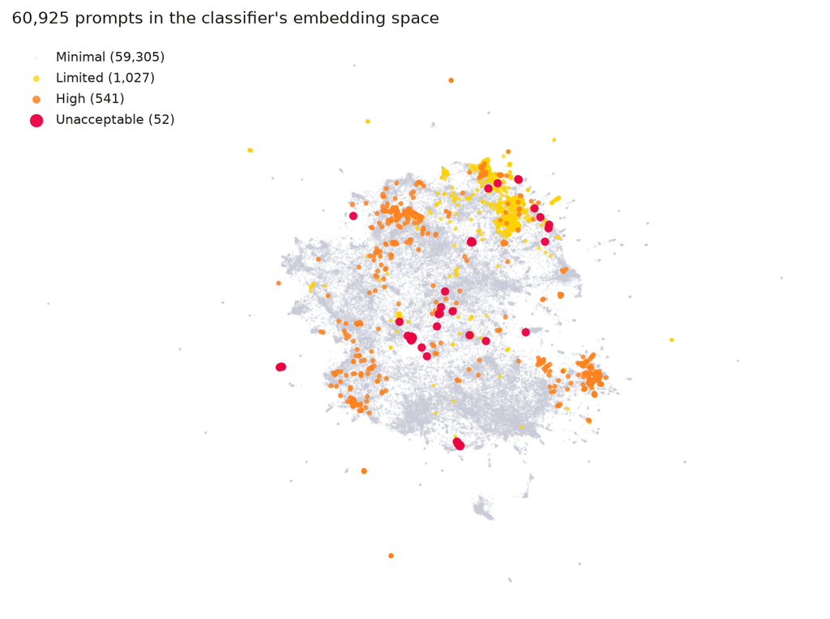

Source: authors’ analysis of ModernBERT embeddings.

Limited prompts form a visible region and High prompts form several partial regions. The 52 Unacceptable prompts remain scattered through the larger Minimal class.

### Additional model comparisons

Approaches tested on earlier or current consensus snapshots:

| Approach | Result |
| --- | --- |
| clustered SVM models | lower performance because rare classes became too small within clusters |
| chunk-level maximum pooling | no improvement for the generally short prompts |
| SetFit contrastive fine-tuning | overfitting on the smallest category |
| retrieval-tuned embedding model | slightly lower classifier performance than the base embedding model |
| tuned LightGBM | AP 0.604 compared with 0.640 for the RBF SVM |

The evidence does not support further model complexity as the first priority. Additional adjudicated severe examples are more likely to improve the system.

### Sampling origin changes the reported performance

Both subsets contain observed prompts and use the same model scores. Synthetic variants appear only in retriever fine-tuning.

| Sampling pathway | n | Severe AP | Unacceptable AP |
| --- | --- | --- | --- |
| initial workbook sample | 3,047 | 0.881 | 0.920 |
| retrieval-selected sample | 57,878 | 0.518 | 0.103 |

**Review and composition**

- every High and Unacceptable label was human-reviewed
- Limited and Minimal labels were checked on sampled rows
- the initial workbook sample contains **73%** of all Unacceptable cases
- pooled Unacceptable AP is **0.62**, compared with **0.10** on retrieval-selected rows

**Warning**

Evaluation on the mixed corpus would overstate performance on the cases encountered by the retrieval pipeline by about six times.

### Probabilities understate risk near the decision threshold

[figure not shown]

Source: authors’ analysis of out-of-fold predictions.

**How to read the plot**

- one point represents one 0.1-wide bin of out-of-fold predictions
- horizontal position: mean predicted probability in the bin
- vertical position: observed share of the class in the bin
- larger points contain more prompts; bins with fewer than five prompts are omitted

**Warning**

**Result.** In one High-risk bin, the model assigns an average probability of 0.28, but 72% of the prompts in that bin are High ($n=277$).

The overall expected calibration error of 0.005 conceals this rare-class error because Minimal prompts dominate the corpus.

### Thresholds raise severe recall from 2% to 61%

**Evaluation setup**

- threshold selection on one half of the retrieved rows
- evaluation on the other half
- results averaged across 40 random splits

| Decision method | Severe recall | Precision | Share flagged |
| --- | --- | --- | --- |
| largest predicted category | 0.021 | n/a | n/a |
| category-specific thresholds | 0.573 | 0.639 | 0.67% |
| binary target with threshold | 0.606 | 0.636 | 0.71% |

**Important**

At the selected operating point, the model identifies 61% of consensus-severe prompts and flags 0.7% of prompts for additional policy handling.

### First feedback experiment

Results from an earlier corpus of 18,247 prompts. We added 130 reviewed disagreement labels and 89 counterfactual negative examples to training only.

| Metric | Consensus labels | With feedback examples |
| --- | --- | --- |
| Macro-F1 | 0.61 | 0.62 |
| High recall | 0.56 | 0.57 |
| Unacceptable recall | 0.44 | 0.53 |
| Severe recall | 0.55 | 0.57 |

The direction is encouraging, but the Unacceptable evaluation contains only 30 examples and the uncertainty intervals overlap.

### Full annotation instruction

The complete 276-line instruction used for language-model labelling is documented in the project repository [14]. It defines four AI Act categories and a fifth label for prompts without a classifiable AI use case.

Its central instruction is to infer the likely intended purpose while treating every prompt as an isolated message. This unavoidable tension explains much of the disagreement observed in the study.